**Question 1** With Markdown write a sentence that has one word in bold.

I will write a sentence that has a one word in **bold**.

**Question 2** With Markdown write a sentence that has one word in italic.

I will write a sentence that has one word in *italic*.

**Question 3** With Markdown write a sentence that has one word in italic bold.

I will write a sentence that has one word in *italicbold*.

**Question 4** With Markdown write an unordered list with three items.

*air

*fire

*earth

**Question 5** With Markdown write an ordered list with three items.

1 apple

2 grape

3 banana

**Question 6** With Markdown give a link to your favorite webpage.

[yoyo chinese!](https://yoyochinese.com/)

**Question 7** With Markdown add a cat picture.

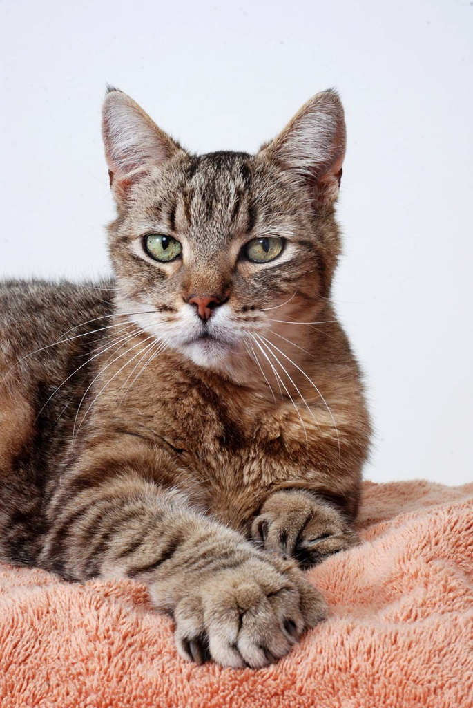

**Question 8** With Rmarkdown insert a code chunk and give an example of a simple mathematical calculation in it.

```r
8-4
```

```
## [1] 4
```

**Question 9** With $LaTeX$ write your favorite equation in block form.

$e=mc^2$.

**Question 10** In a code chunk calculate 3 + 4.

```r
3 + 4
```

```
## [1] 7
```